# Reproducible Research: Peer Assessment 1

## Loading and preprocessing the data

downloading and unziping the csv file

```r
if (file.exists("activity.csv")==FALSE)
    {
    temp <- tempfile()
    URL <- c("https://github.com/talkalovski/RepData_PeerAssessment1/blob/ea9cc6573bd7e4212a709c1168b573a42a1726ac/activity.zip?raw=true.zip")
    download.file(URL,temp, mode="wb")
    unzip(temp, "activity.csv")
    }
```

reading and processing the data

```r
act <- read.csv("activity.csv")
act$date <- as.Date(act$date, format = "%Y-%m-%d")
```

## What is mean total number of steps taken per day?

Calculate the total number of steps taken per day

```r
sumday <- setNames(aggregate(act$steps~act$date, FUN=sum),c("date","sum_steps"))
```

Make a histogram of the total number of steps taken each day

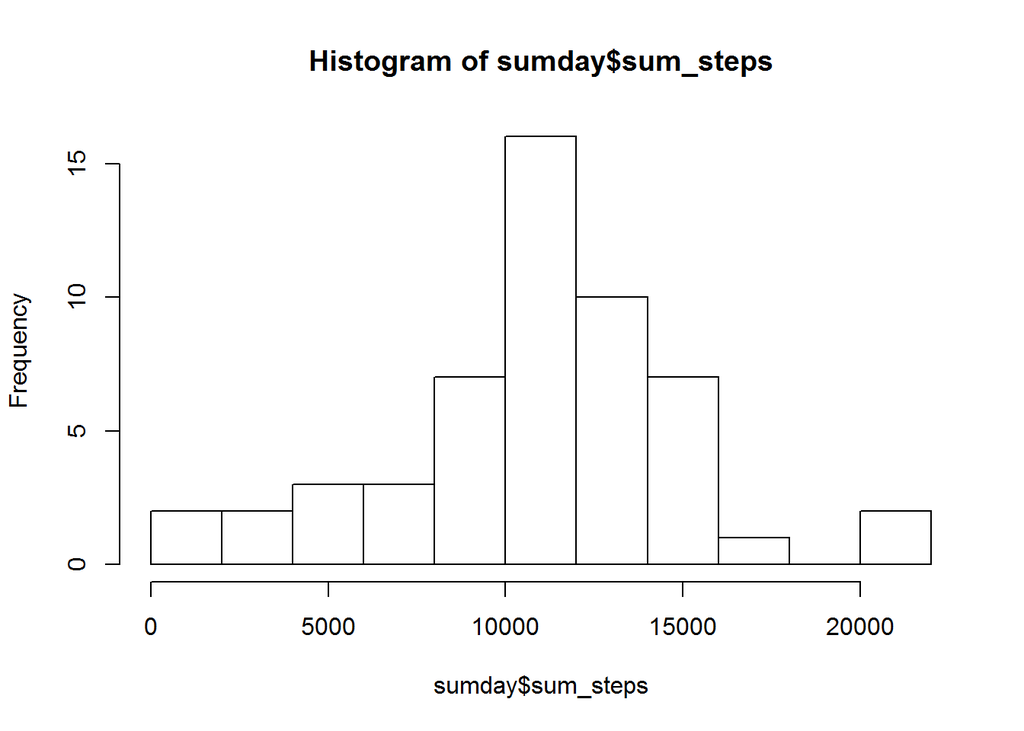

```r
hist(sumday$sum_steps,breaks = 8)
```

Calculate and report the mean and median of the total number of steps taken per day

```r
mean(sumday$sum_steps)
```

```
## [1] 10766.19
```

```r
median(sumday$sum_steps)
```

```
## [1] 10765
```

## What is the average daily activity pattern?

Calculate the average number of steps taken per interval across all days.

```r
  intmean <- setNames(aggregate(act$steps~act$interval, FUN=mean),c("interval","steps_mean"))
```

plot the average daily activity - number of steps taken per interval.

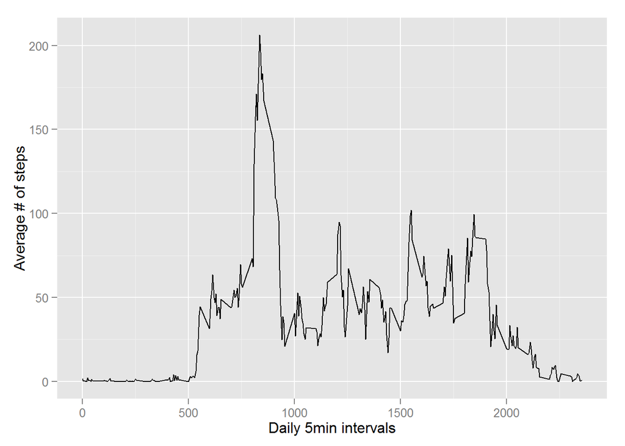

```r
library("ggplot2")
ggplot(intmean, aes(interval, steps_mean)) + geom_line()+
xlab("Daily 5min intervals")+ylab("Average # of steps")
```

calculate the 5-minute interval that contains the maximum number of steps on average.

```r
subset(intmean, steps_mean==max(steps_mean))
```

```
##     interval steps_mean
## 104      835   206.1698
```

## Imputing missing values

clculating the number of NA’s in thedataset (missing values)

```r
sum(is.na(act$steps))
```

```
## [1] 2304
```

my strategy for filling in all of the missing values in the dataset, is to impute the mean value of the specific interval across all other days.

Create a new dataset that is equal to the original dataset but with the missing data filled in.

```r
fillact <- act
fillact$Msteps <- intmean$steps_mean

for (i in 1:nrow(fillact))
  if (is.na(fillact$steps[i]))
    fillact$steps[i] = fillact$Msteps[i]
```

Make a histogram of the total number of steps taken each day.

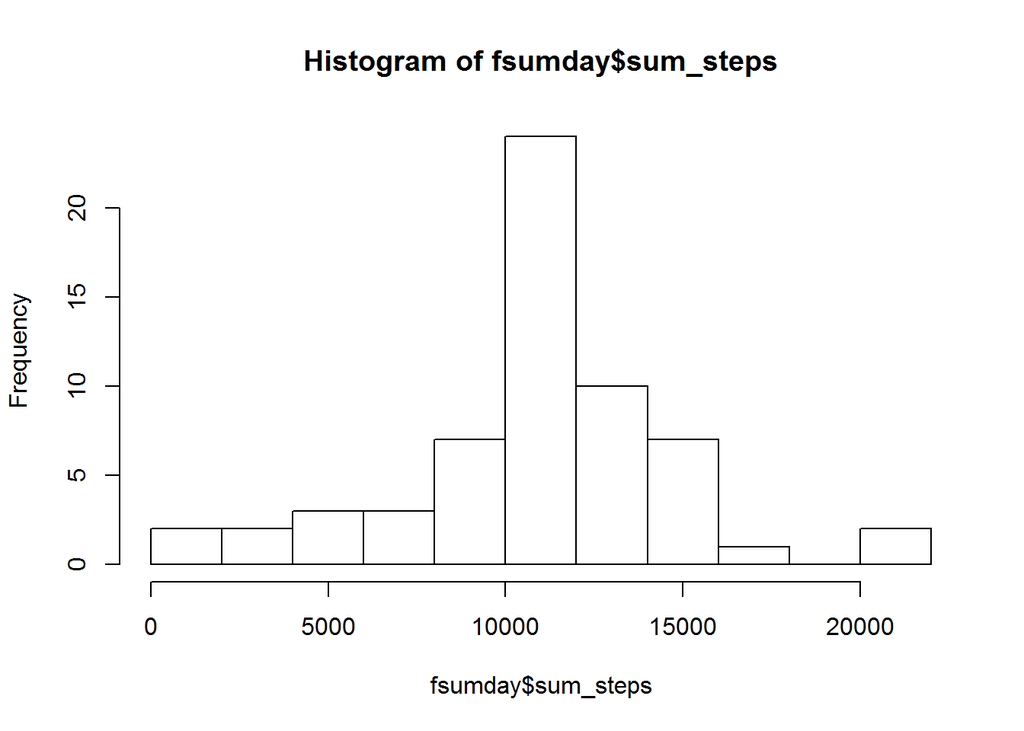

```r
  fsumday <- setNames(aggregate(fillact$steps~fillact$date, FUN=sum),c("date","sum_steps"))
  hist(fsumday$sum_steps,breaks = 8)
```

Calculate and report the mean and median of the total number of steps taken per day

```r
  mean(fsumday$sum_steps)
```

```
## [1] 10766.19
```

```r
  median(fsumday$sum_steps)
```

```
## [1] 10766.19
```

## Are there differences in activity patterns between weekdays and weekends?

Create a new factor variable in the dataset with two levels - “weekday” and “weekend.

```r
    fillact$date <- as.Date(act$date, format = "%Y-%m-%d")
    fillact$weekday <- weekdays(fillact$date)


     for (i in 1:nrow(fillact))
        if  (fillact$weekday[i]=="Friday"|fillact$weekday[i]=="Saturday")
        fillact$weekpart[i] ="Weekend" else fillact$weekpart[i] ="Weekday"
```

Make time serise plot to compare the average dayly actiity between weekdays and weekend.

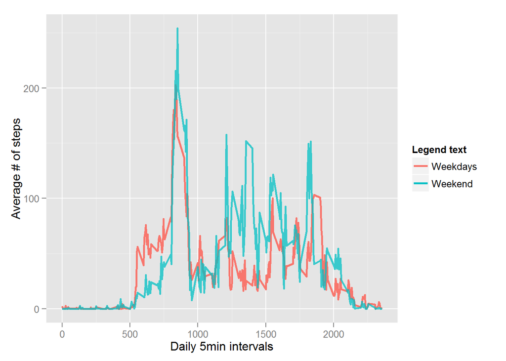

```r
    wd <- fillact [fillact$weekpart=="Weekday",]
    we <- fillact [fillact$weekpart=="Weekend",]


    wdintmean <- setNames(aggregate(wd$steps~wd$interval, FUN=mean),c("interval","steps_mean"))
    weintmean <- setNames(aggregate(we$steps~we$interval, FUN=mean),c("interval","steps_mean"))

    ggplot(wdintmean,aes(interval, steps_mean))+geom_line(aes(color="Weekdays"),size=1)+
      geom_line(data=weintmean,aes(color="Weekend"),size=1,alpha=3/4)+
      labs(color="Legend text")+   xlab("Daily 5min intervals") + ylab("Average # of steps")
```

I think the comparison shows that this person tesnd to sleep late in the weekend, but then on during the day he is more active.